# imdbtop1000project

Hello, and welcome to my first project in hopefully what will be a long career in data analysis. Today i’m going to be attempting to analyze different elements from a dataset containing the top 1000 movies from IMDB. I’ve obtained this dataset from kaggle which can be accessed through this link: https://www.kaggle.com/datasets/omarhanyy/imdb-top-1000.

Today I will be analyzing the following elements:

1. Movie count by decade.
2. Which successful primary actor (‘star 1’ in dataset) is the most successful with at least 3 movies.
3. Which supporting actor (‘star 2’ in dataset) is the most successful with at least 2 movies.
4. The most successful directors with at least 3 movies. 5.Which secondary supporting actor is the most successful with at least 2 movies.
5. What is the movie proportion by genre.
6. What is the average runtime of movies by year in the last century.
7. Count of movies by year.

The first thing I will do is install all necessary packages:

Now I will load them :

```r
library(tidyverse)
library(tidyr)
library(dplyr)
library(janitor)
```

```r
library(ggplot2)
library(ggthemes)
```

Now that everything is installed and loaded I will load the data into R using the read.csv function.

```r
imdbtop1000 <-read.csv("~/Downloads/imdb_top_1000.csv", sep = ",")
```

Now that the data is loaded the first thing I’m going to do sort through and clean the data.

The first thing I inspected were the field names. There were no misspellings or duplicates in the field names, however many of the names were typed in titlecase. I will use the clean_names() function from the janitor packages to fix this.

```r
imdbtop1000v1 <- imdbtop1000%>%
  clean_names()
```

The next thing I inspected was whether or not there were any empty columns or rows and there were none.

Now i’ll check for duplicates using the get_dupes function.

```r
imdbtop1000v1 %>%
  get_dupes(poster_link)
```

```
## No duplicate combinations found of: poster_link
```

| poster_link | dupe_count | series_title | released_year | certificate | runtime | genre | imdb_rating | overview | meta_score | director | star1 | star2 | star3 | star4 | no_of_votes | gross |
| --- | --- | --- | --- | --- | --- | --- | --- | --- | --- | --- | --- | --- | --- | --- | --- | --- |

After checking to see if there are any duplicates, which there isn’t, ill check for any missing values using the summary function.

```r
summary(imdbtop1000v1)
```

```
##  poster_link        series_title       released_year      certificate
##  Length:1000        Length:1000        Length:1000        Length:1000
##  Class :character   Class :character   Class :character   Class :character
##  Mode  :character   Mode  :character   Mode  :character   Mode  :character
##
##
##
##
##    runtime             genre            imdb_rating      overview
##  Length:1000        Length:1000        Min.   :7.600   Length:1000
##  Class :character   Class :character   1st Qu.:7.700   Class :character
##  Mode  :character   Mode  :character   Median :7.900   Mode  :character
##                                        Mean   :7.949
##                                        3rd Qu.:8.100
##                                        Max.   :9.300
##
##    meta_score       director            star1              star2
##  Min.   : 28.00   Length:1000        Length:1000        Length:1000
##  1st Qu.: 70.00   Class :character   Class :character   Class :character
##  Median : 79.00   Mode  :character   Mode  :character   Mode  :character
##  Mean   : 77.97
##  3rd Qu.: 87.00
##  Max.   :100.00
##  NA's   :157
##     star3              star4            no_of_votes         gross
##  Length:1000        Length:1000        Min.   :  25088   Length:1000
##  Class :character   Class :character   1st Qu.:  55526   Class :character
##  Mode  :character   Mode  :character   Median : 138548   Mode  :character
##                                        Mean   : 273693
##                                        3rd Qu.: 374161
##                                        Max.   :2343110
##
```

After running the summary function I notive that there are 157 null values in the metascore column, I will replace those null values with the average meta score across the whole dataset, which can be rounded to 78.

```r
imdbtop1000v2 <- imdbtop1000v1 %>%
  mutate(meta_score = coalesce(meta_score, 78))
```

I will then check again for any null values.

```r
summary(imdbtop1000v2)
```

```
##  poster_link        series_title       released_year      certificate
##  Length:1000        Length:1000        Length:1000        Length:1000
##  Class :character   Class :character   Class :character   Class :character
##  Mode  :character   Mode  :character   Mode  :character   Mode  :character
##
##
##
##    runtime             genre            imdb_rating      overview
##  Length:1000        Length:1000        Min.   :7.600   Length:1000
##  Class :character   Class :character   1st Qu.:7.700   Class :character
##  Mode  :character   Mode  :character   Median :7.900   Mode  :character
##                                        Mean   :7.949
##                                        3rd Qu.:8.100
##                                        Max.   :9.300
##    meta_score       director            star1              star2
##  Min.   : 28.00   Length:1000        Length:1000        Length:1000
##  1st Qu.: 72.00   Class :character   Class :character   Class :character
##  Median : 78.00   Mode  :character   Mode  :character   Mode  :character
##  Mean   : 77.98
##  3rd Qu.: 85.25
##  Max.   :100.00
##     star3              star4            no_of_votes         gross
##  Length:1000        Length:1000        Min.   :  25088   Length:1000
##  Class :character   Class :character   1st Qu.:  55526   Class :character
##  Mode  :character   Mode  :character   Median : 138548   Mode  :character
##                                        Mean   : 273693
##                                        3rd Qu.: 374161
##                                        Max.   :2343110
```

After I ran the summary function I was able to confirm that there are no longer any null values in the dataset.

The next thing I need to do is check for any missplaced values.

```r
imdbtop1000v2 %>%
  count(released_year)
```

| released_year | n |
| --- | --- |
| 1920 | 1 |
| 1921 | 1 |
| 1922 | 1 |
| 1924 | 1 |
| 1925 | 2 |
| 1926 | 1 |
| 1927 | 2 |
| 1928 | 2 |
| 1930 | 1 |
| 1931 | 3 |

[output cut: 90 more lines]

After checking all the released_year I see that ‘PG’ is accidentally placed into the ‘released_year’ column. So I will located where that ‘PG’ is located.

```r
imdbtop1000v2%>%
  filter(released_year == 'PG')
```

| poster_link | series_title | released_year | certificate | runtime | genre | imdb_rating | overview | meta_score | director | star1 | star2 | star3 | star4 | no_of_votes | gross |
| --- | --- | --- | --- | --- | --- | --- | --- | --- | --- | --- | --- | --- | --- | --- | --- |
| https://m.media-amazon.com/images/M/MV5BNjEzYjJmNzgtNDkwNy00MTQ4LTlmMWMtNzA4YjE2NjI0ZDg4XkEyXkFqcGdeQXVyNjU0OTQ0OTY@._V1_UX67_CR0,0,67,98_AL_.jpg | Apollo 13 | PG | U | 140 min | Adventure, Drama, History | 7.6 | NASA must devise a strategy to return Apollo 13 to Earth safely after the spacecraft undergoes massive internal damage putting the lives of the three astronauts on board in jeopardy. | 77 | Ron Howard | Tom Hanks | Bill Paxton | Kevin Bacon | Gary Sinise | 269197 | 173,837,933 |

After pulling the record for the misplaced ‘PG’ I find that it’s for the movie ‘Apollo 13’ so I will replace the ‘PG’ with what I found after doing research the actually releasd date, which is 1995, and the certificate is indeed ‘PG’ so I will replace that as well.

```r
imdbtop1000v4 <- imdbtop1000v2 %>%
  mutate(released_year = str_replace(released_year, 'PG', '1995'))

imdbtop1000v4 <- imdbtop1000v4 %>%
  mutate(certificate = str_replace(certificate, 'U', 'PG'))
```

After I replaced both those observations with the corresponding correct observations I will check to confirm it was indeed changed and also check all other fields for misplaced observations.

```r
imdbtop1000v4%>%
  filter(series_title == 'Apollo 13')
```

| poster_link | series_title | released_year | certificate | runtime | genre | imdb_rating | overview | meta_score | director | star1 | star2 | star3 | star4 | no_of_votes | gross |
| --- | --- | --- | --- | --- | --- | --- | --- | --- | --- | --- | --- | --- | --- | --- | --- |
| https://m.media-amazon.com/images/M/MV5BNjEzYjJmNzgtNDkwNy00MTQ4LTlmMWMtNzA4YjE2NjI0ZDg4XkEyXkFqcGdeQXVyNjU0OTQ0OTY@._V1_UX67_CR0,0,67,98_AL_.jpg | Apollo 13 | 1995 | PG | 140 min | Adventure, Drama, History | 7.6 | NASA must devise a strategy to return Apollo 13 to Earth safely after the spacecraft undergoes massive internal damage putting the lives of the three astronauts on board in jeopardy. | 77 | Ron Howard | Tom Hanks | Bill Paxton | Kevin Bacon | Gary Sinise | 269197 | 173,837,933 |

```r
imdbtop1000v4%>%
  count(certificate)
```

| certificate | n |
| --- | --- |
|  | 101 |
| 16 | 1 |
| A | 197 |
| Approved | 11 |
| G | 12 |
| GP | 2 |
| PG | 271 |
| PG-13 | 43 |
| PG/A | 1 |
| PGA | 175 |

[output cut: 6 more lines]

After running the count for certificate I see one observation that shows a 16 I will investigate this further…

```r
imdbtop1000v4%>%
  filter(certificate == 16)
```

| poster_link | series_title | released_year | certificate | runtime | genre | imdb_rating | overview | meta_score | director | star1 | star2 | star3 | star4 | no_of_votes | gross |
| --- | --- | --- | --- | --- | --- | --- | --- | --- | --- | --- | --- | --- | --- | --- | --- |
| https://m.media-amazon.com/images/M/MV5BZGRkOGMxYTUtZTBhYS00NzI3LWEzMDQtOWRhMmNjNjJjMzM4XkEyXkFqcGdeQXVyMTMxODk2OTU@._V1_UY98_CR0,0,67,98_AL_.jpg | Koe no katachi | 2016 | 16 | 130 min | Animation, Drama, Family | 8.1 | A young man is ostracized by his classmates after he bullies a deaf girl to the point where she moves away. Years later, he sets off on a path for redemption. | 78 | Naoko Yamada | Miyu Irino | Saori Hayami | Aoi Yûki | Kenshô Ono | 47708 |  |

```r
imdbtop1000v4%>%
  filter(certificate == 'PGnrated')
```

| poster_link | series_title | released_year | certificate | runtime | genre | imdb_rating | overview | meta_score | director | star1 | star2 | star3 | star4 | no_of_votes | gross |
| --- | --- | --- | --- | --- | --- | --- | --- | --- | --- | --- | --- | --- | --- | --- | --- |
| https://m.media-amazon.com/images/M/MV5BMjRjMTYwMTYtMmRkNi00MmVkLWE0MjQtNmM3YjI0NWFhZDNmXkEyXkFqcGdeQXVyODE5NzE3OTE@._V1_UX67_CR0,0,67,98_AL_.jpg | Dil Chahta Hai | 2001 | PGnrated | 183 min | Comedy, Drama, Romance | 8.1 | Three inseparable childhood friends are just out of college. Nothing comes between them - until they each fall in love, and their wildly different approaches to relationships creates tension. | 78 | Farhan Akhtar | Aamir Khan | Saif Ali Khan | Akshaye Khanna | Preity Zinta | 66803 | 300,000 |

After looking at the certificates I see one of the ratings is simply a number of 16, after researching I was able to find that there is no rating for this moving so I will change this to NA along with 101 other blank values. Another thing I noticed is that there are two different ‘PGA’ observations one with a forward slash and one without the one with a forward slash I will change to ‘PGA’. There was an additional rating of ‘PGnated’ after doing research I found out that movie is actually not rated so it will get a null value as well.

```r
imdbtop1000v4 %>%
  count(certificate)
```

| certificate | n |
| --- | --- |
|  | 101 |
| 16 | 1 |
| A | 197 |
| Approved | 11 |
| G | 12 |
| GP | 2 |
| PG | 271 |
| PG-13 | 43 |
| PG/A | 1 |
| PGA | 175 |

[output cut: 6 more lines]

```r
imdbtop1000v7<- imdbtop1000v4%>%
  mutate(certifcate = str_replace(certificate, "NA", "None"))

imdbtop1000v7 <- imdbtop1000v4%>%
  mutate(certificate = str_replace(certificate, "PG/A", "PGA"))

imdbtop1000v7 <- imdbtop1000v7%>%
  mutate(certificate = str_replace(certificate, "PGnrated", ""))

imdbtop1000v7 <- imdbtop1000v7%>%
  mutate(certificate = str_replace(certificate, 'NA', ""))

imdbtop1000v7 <- imdbtop1000v7 %>%
  mutate(across(where(is.character), ~ na_if(.,"")))
```

After cleaning up the certificate column I will check the other columns for uniformity.

```r
imdbtop1000v7 %>%
  count(genre)
```

| genre | n |
| --- | --- |
| Action, Adventure | 5 |
| Action, Adventure, Biography | 1 |
| Action, Adventure, Comedy | 10 |
| Action, Adventure, Crime | 1 |
| Action, Adventure, Drama | 14 |
| Action, Adventure, Family | 1 |
| Action, Adventure, Fantasy | 6 |
| Action, Adventure, History | 1 |
| Action, Adventure, Horror | 1 |
| Action, Adventure, Mystery | 1 |

[output cut: 192 more lines]

That was my last step in the cleaning process so now I move on to what is referred to as the ‘analyze’ step in the data analytics process. The first thing I’m going to try to analyze is the movie count by decade. One of the things that is obvious after looking at the data is there is no decade column to make this process easier, the first thing I need to do is figure what is the eariest year and the latest year in the dataset, so I know where to begin and end my case statement.

```r
imdbtop1000v7%>%
  slice_max(released_year, n = 1)
```

| poster_link | series_title | released_year | certificate | runtime | genre | imdb_rating | overview | meta_score | director | star1 | star2 | star3 | star4 | no_of_votes | gross |
| --- | --- | --- | --- | --- | --- | --- | --- | --- | --- | --- | --- | --- | --- | --- | --- |
| https://m.media-amazon.com/images/M/MV5BNjViNWRjYWEtZTI0NC00N2E3LTk0NGQtMjY4NTM3OGNkZjY0XkEyXkFqcGdeQXVyMjUxMTY3ODM@._V1_UX67_CR0,0,67,98_AL_.jpg | Hamilton | 2020 | PG-13 | 160 min | Biography, Drama, History | 8.6 | The real life of one of America's foremost founding fathers and first Secretary of the Treasury, Alexander Hamilton. Captured live on Broadway from the Richard Rodgers Theater with the original Broadw… | 90 | Thomas Kail | Lin-Manuel Miranda | Phillipa Soo | Leslie Odom Jr. | Renée Elise Goldsberry | 55291 | NA |
| https://m.media-amazon.com/images/M/MV5BOTc2ZTlmYmItMDBhYS00YmMzLWI4ZjAtMTI5YTBjOTFiMGEwXkEyXkFqcGdeQXVyODE5NzE3OTE@._V1_UY98_CR0,0,67,98_AL_.jpg | Soorarai Pottru | 2020 | PG | 153 min | Drama | 8.6 | Nedumaaran Rajangam "Maara" sets out to make the common man fly and in the process takes on the world's most capital intensive industry and several enemies who stand in his way. | 78 | Sudha Kongara | Suriya | Madhavan | Paresh Rawal | Aparna Balamurali | 54995 | NA |
| https://m.media-amazon.com/images/M/MV5BZGE1MDg5M2MtNTkyZS00MTY5LTg1YzUtZTlhZmM1Y2EwNmFmXkEyXkFqcGdeQXVyNjA3OTI0MDc@._V1_UX67_CR0,0,67,98_AL_.jpg | Soul | 2020 | PG | 100 min | Animation, Adventure, Comedy | 8.1 | After landing the gig of a lifetime, a New York jazz pianist suddenly finds himself trapped in a strange land between Earth and the afterlife. | 83 | Pete Docter | Kemp Powers | Jamie Foxx | Tina Fey | Graham Norton | 159171 | NA |
| https://m.media-amazon.com/images/M/MV5BNmI0MTliMTAtMmJhNC00NTJmLTllMzQtMDI3NzA1ODMyZWI1XkEyXkFqcGdeQXVyODE5NzE3OTE@._V1_UY98_CR5,0,67,98_AL_.jpg | Dil Bechara | 2020 | PGA | 101 min | Comedy, Drama, Romance | 7.9 | The emotional journey of two hopelessly in love youngsters, a young girl, Kizie, suffering from cancer, and a boy, Manny, whom she meets at a support group. | 78 | Mukesh Chhabra | Sushant Singh Rajput | Sanjana Sanghi | Sahil Vaid | Saswata Chatterjee | 111478 | NA |
| https://m.media-amazon.com/images/M/MV5BYjYzOGE1MjUtODgyMy00ZDAxLTljYTgtNzk0Njg2YWQwMTZhXkEyXkFqcGdeQXVyMDM2NDM2MQ@@._V1_UX67_CR0,0,67,98_AL_.jpg | The Trial of the Chicago 7 | 2020 | R | 129 min | Drama, History, Thriller | 7.8 | The story of 7 people on trial stemming from various charges surrounding the uprising at the 1968 Democratic National Convention in Chicago, Illinois. | 77 | Aaron Sorkin | Eddie Redmayne | Alex Sharp | Sacha Baron Cohen | Jeremy Strong | 89896 | NA |
| https://m.media-amazon.com/images/M/MV5BOTNjM2Y2ZjgtMDc5NS00MDQ1LTgyNGYtYzYwMTAyNWQwYTMyXkEyXkFqcGdeQXVyMjE4NzUxNDA@._V1_UX67_CR0,0,67,98_AL_.jpg | Druk | 2020 | NA | 117 min | Comedy, Drama | 7.8 | Four friends, all high school teachers, test a theory that they will improve their lives by maintaining a constant level of alcohol in their blood. | 81 | Thomas Vinterberg | Mads Mikkelsen | Thomas Bo Larsen | Magnus Millang | Lars Ranthe | 33931 | NA |

now the minimum…

```r
imdbtop1000v7%>%
  slice_min(released_year, n = 1)
```

| poster_link | series_title | released_year | certificate | runtime | genre | imdb_rating | overview | meta_score | director | star1 | star2 | star3 | star4 | no_of_votes | gross |
| --- | --- | --- | --- | --- | --- | --- | --- | --- | --- | --- | --- | --- | --- | --- | --- |
| https://m.media-amazon.com/images/M/MV5BNWJiNGJiMTEtMGM3OC00ZWNlLTgwZTgtMzdhNTRiZjk5MTQ1XkEyXkFqcGdeQXVyMTMxODk2OTU@._V1_UY98_CR1,0,67,98_AL_.jpg | Das Cabinet des Dr. Caligari | 1920 | NA | 76 min | Fantasy, Horror, Mystery | 8.1 | Hypnotist Dr. Caligari uses a somnambulist, Cesare, to commit murders. | 78 | Robert Wiene | Werner Krauss | Conrad Veidt | Friedrich Feher | Lil Dagover | 57428 | NA |

After find the min and max release year I will use a case_when statement to assign each movie to its appropiate decade in a new column which will be named ‘decade’.

```r
imdbtop1000v8 <- imdbtop1000v7 %>%
  mutate(decade = case_when(released_year >= 1920 & released_year < 1930 ~ 1920,
                            released_year >= 1930 & released_year < 1940 ~ 1930,
                            released_year >= 1940 & released_year < 1950 ~ 1940,
                            released_year >= 1950 & released_year < 1960 ~ 1950,
                            released_year >= 1960 & released_year < 1970 ~ 1960,
                            released_year >= 1970 & released_year < 1980 ~ 1970,
                            released_year >= 1980 & released_year < 1990 ~ 1980,
                            released_year >= 1990 & released_year < 2000 ~ 1990,
                            released_year >= 2000 & released_year < 2010 ~ 2000,
                            released_year >= 2010 & released_year < 2020 ~ 2010,
                            released_year >= 2020 & released_year < 2030 ~ 2020))
```

```r
head(imdbtop1000v8, n = 12)
```

|  | poster_link | series_title | released_year | certificate | runtime | genre | imdb_rating | overview | meta_score | director | star1 | star2 | star3 | star4 | no_of_votes | gross | decade |
| --- | --- | --- | --- | --- | --- | --- | --- | --- | --- | --- | --- | --- | --- | --- | --- | --- | --- |
| 1 | https://m.media-amazon.com/images/M/MV5BMDFkYTc0MGEtZmNhMC00ZDIzLWFmNTEtODM1ZmRlYWMwMWFmXkEyXkFqcGdeQXVyMTMxODk2OTU@._V1_UX67_CR0,0,67,98_AL_.jpg | The Shawshank Redemption | 1994 | A | 142 min | Drama | 9.3 | Two imprisoned men bond over a number of years, finding solace and eventual redemption through acts of common decency. | 80 | Frank Darabont | Tim Robbins | Morgan Freeman | Bob Gunton | William Sadler | 2343110 | 28,341,469 | 1990 |
| 2 | https://m.media-amazon.com/images/M/MV5BM2MyNjYxNmUtYTAwNi00MTYxLWJmNWYtYzZlODY3ZTk3OTFlXkEyXkFqcGdeQXVyNzkwMjQ5NzM@._V1_UY98_CR1,0,67,98_AL_.jpg | The Godfather | 1972 | A | 175 min | Crime, Drama | 9.2 | An organized crime dynasty's aging patriarch transfers control of his clandestine empire to his reluctant son. | 100 | Francis Ford Coppola | Marlon Brando | Al Pacino | James Caan | Diane Keaton | 1620367 | 134,966,411 | 1970 |
| 3 | https://m.media-amazon.com/images/M/MV5BMTMxNTMwODM0NF5BMl5BanBnXkFtZTcwODAyMTk2Mw@@._V1_UX67_CR0,0,67,98_AL_.jpg | The Dark Knight | 2008 | PGA | 152 min | Action, Crime, Drama | 9.0 | When the menace known as the Joker wreaks havoc and chaos on the people of Gotham, Batman must accept one of the greatest psychological and physical tests of his ability to fight injustice. | 84 | Christopher Nolan | Christian Bale | Heath Ledger | Aaron Eckhart | Michael Caine | 2303232 | 534,858,444 | 2000 |
| 4 | https://m.media-amazon.com/images/M/MV5BMWMwMGQzZTItY2JlNC00OWZiLWIyMDctNDk2ZDQ2YjRjMWQ0XkEyXkFqcGdeQXVyNzkwMjQ5NzM@._V1_UY98_CR1,0,67,98_AL_.jpg | The Godfather: Part II | 1974 | A | 202 min | Crime, Drama | 9.0 | The early life and career of Vito Corleone in 1920s New York City is portrayed, while his son, Michael, expands and tightens his grip on the family crime syndicate. | 90 | Francis Ford Coppola | Al Pacino | Robert De Niro | Robert Duvall | Diane Keaton | 1129952 | 57,300,000 | 1970 |
| 5 | https://m.media-amazon.com/images/M/MV5BMWU4N2FjNzYtNTVkNC00NzQ0LTg0MjAtYTJlMjFhNGUxZDFmXkEyXkFqcGdeQXVyNjc1NTYyMjg@._V1_UX67_CR0,0,67,98_AL_.jpg | 12 Angry Men | 1957 | PG | 96 min | Crime, Drama | 9.0 | A jury holdout attempts to prevent a miscarriage of justice by forcing his colleagues to reconsider the evidence. | 96 | Sidney Lumet | Henry Fonda | Lee J. Cobb | Martin Balsam | John Fiedler | 689845 | 4,360,000 | 1950 |
| 6 | https://m.media-amazon.com/images/M/MV5BNzA5ZDNlZWMtM2NhNS00NDJjLTk4NDItYTRmY2EwMWZlMTY3XkEyXkFqcGdeQXVyNzkwMjQ5NzM@._V1_UX67_CR0,0,67,98_AL_.jpg | The Lord of the Rings: The Return of the King | 2003 | PG | 201 min | Action, Adventure, Drama | 8.9 | Gandalf and Aragorn lead the World of Men against Sauron's army to draw his gaze from Frodo and Sam as they approach Mount Doom with the One Ring. | 94 | Peter Jackson | Elijah Wood | Viggo Mortensen | Ian McKellen | Orlando Bloom | 1642758 | 377,845,905 | 2000 |
| 7 | https://m.media-amazon.com/images/M/MV5BNGNhMDIzZTUtNTBlZi00MTRlLWFjM2ItYzViMjE3YzI5MjljXkEyXkFqcGdeQXVyNzkwMjQ5NzM@._V1_UY98_CR0,0,67,98_AL_.jpg | Pulp Fiction | 1994 | A | 154 min | Crime, Drama | 8.9 | The lives of two mob hitmen, a boxer, a gangster and his wife, and a pair of diner bandits intertwine in four tales of violence and redemption. | 94 | Quentin Tarantino | John Travolta | Uma Thurman | Samuel L. Jackson | Bruce Willis | 1826188 | 107,928,762 | 1990 |
| 8 | https://m.media-amazon.com/images/M/MV5BNDE4OTMxMTctNmRhYy00NWE2LTg3YzItYTk3M2UwOTU5Njg4XkEyXkFqcGdeQXVyNjU0OTQ0OTY@._V1_UX67_CR0,0,67,98_AL_.jpg | Schindler's List | 1993 | A | 195 min | Biography, Drama, History | 8.9 | In German-occupied Poland during World War II, industrialist Oskar Schindler gradually becomes concerned for his Jewish workforce after witnessing their persecution by the Nazis. | 94 | Steven Spielberg | Liam Neeson | Ralph Fiennes | Ben Kingsley | Caroline Goodall | 1213505 | 96,898,818 | 1990 |
| 9 | https://m.media-amazon.com/images/M/MV5BMjAxMzY3NjcxNF5BMl5BanBnXkFtZTcwNTI5OTM0Mw@@._V1_UX67_CR0,0,67,98_AL_.jpg | Inception | 2010 | PGA | 148 min | Action, Adventure, Sci-Fi | 8.8 | A thief who steals corporate secrets through the use of dream-sharing technology is given the inverse task of planting an idea into the mind of a C.E.O. | 74 | Christopher Nolan | Leonardo DiCaprio | Joseph Gordon-Levitt | Elliot Page | Ken Watanabe | 2067042 | 292,576,195 | 2010 |
| 10 | https://m.media-amazon.com/images/M/MV5BMmEzNTkxYjQtZTc0MC00YTVjLTg5ZTEtZWMwOWVlYzY0NWIwXkEyXkFqcGdeQXVyNzkwMjQ5NzM@._V1_UX67_CR0,0,67,98_AL_.jpg | Fight Club | 1999 | A | 139 min | Drama | 8.8 | An insomniac office worker and a devil-may-care soapmaker form an underground fight club that evolves into something much, much more. | 66 | David Fincher | Brad Pitt | Edward Norton | Meat Loaf | Zach Grenier | 1854740 | 37,030,102 | 1990 |

[output cut: 2 more lines]

After confirming that the decade column is indeed there, I will then count the number of movies by decade.

```r
imdbtop1000v8moviecountbd <- imdbtop1000v8%>%
  group_by(decade)%>%
  summarize(number_of_movies = n())

imdbtop1000v8moviecountbd
```

| decade | number_of_movies |
| --- | --- |
| 1920 | 11 |
| 1930 | 24 |
| 1940 | 35 |
| 1950 | 56 |
| 1960 | 73 |
| 1970 | 76 |
| 1980 | 89 |
| 1990 | 151 |
| 2000 | 237 |
| 2010 | 242 |

[output cut: 1 more lines]

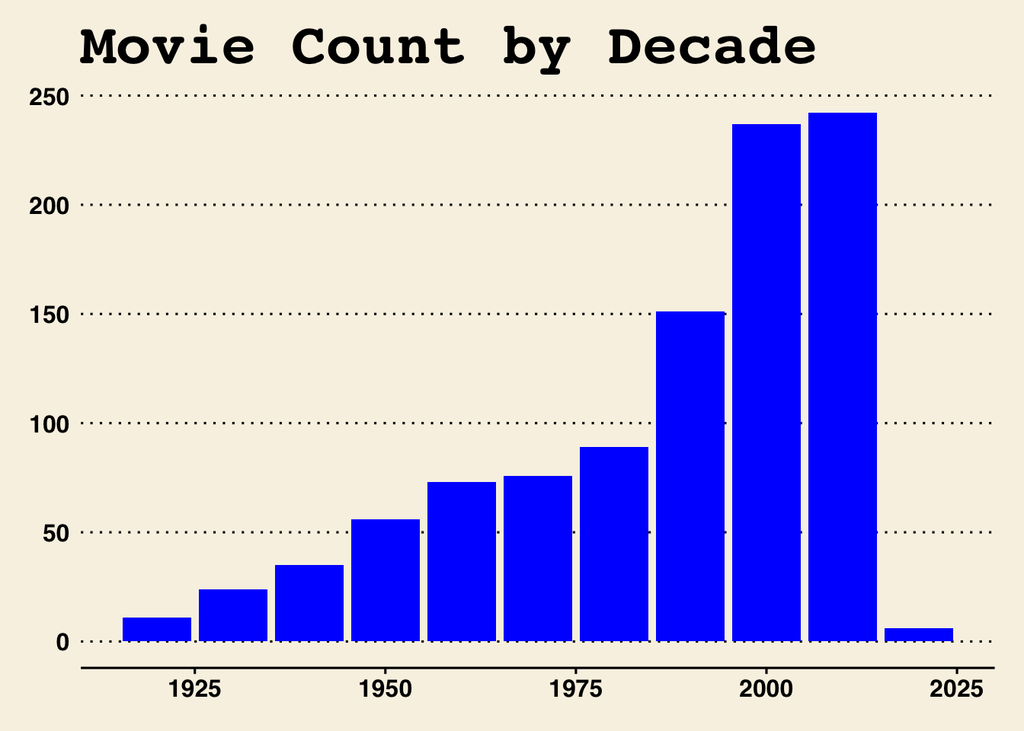

```r
imdbtopcountbdviz <- ggplot(imdbtop1000v8moviecountbd,aes(decade, number_of_movies))+
  geom_bar(fill = "blue", stat = "identity")+
  theme_wsj()+
  labs(title = "Movie Count by Decade")

print(imdbtopcountbdviz)
```

Another thing I’m curious about is which decades contains movies with an ‘imdb’ rating of 8.5 or higher. I will get the count and vizualize this.

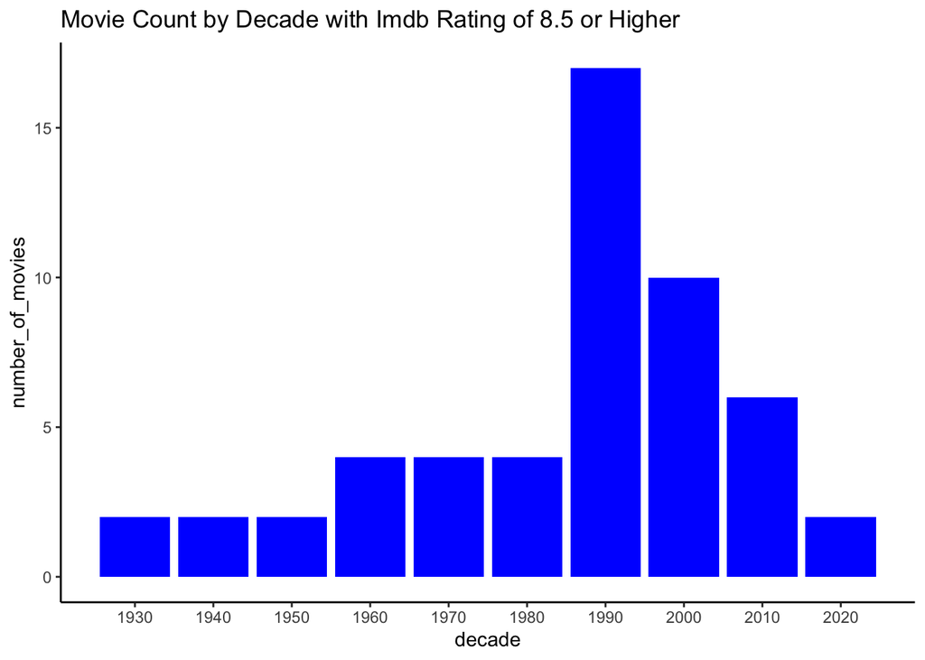

```r
imdb8.5highercountbd <- imdbtop1000v8%>%
  filter(imdb_rating >= 8.5)%>%
  group_by(decade)%>%
  summarize(number_of_movies = n())

ggplot(imdb8.5highercountbd, aes(decade, number_of_movies))+
  geom_bar(fill = "blue", stat= "identity")+
  scale_x_continuous(breaks = seq(1930, 2020, by =10))+
  theme_classic()+
  labs(title = "Movie Count by Decade with Imdb Rating of 8.5 or Higher")
```

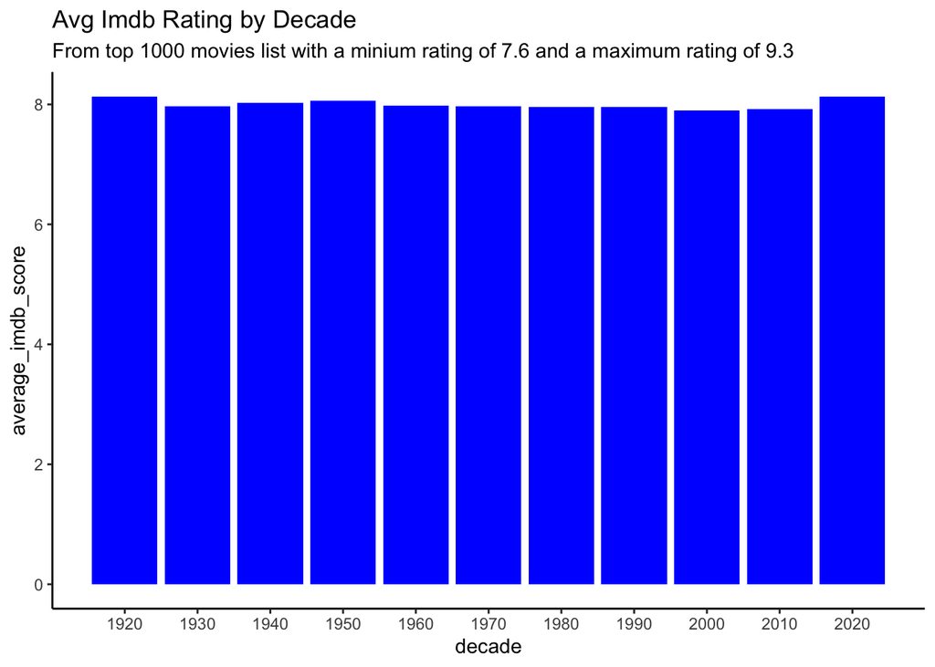

```r
imdbavgimdbbd <- imdbtop1000v8 %>%
  group_by(decade)%>%
  summarize(average_imdb_score = mean(imdb_rating))

idmbavgimdbbdviz <- ggplot(imdbavgimdbbd, aes(decade, average_imdb_score))+
  geom_bar(fill = "blue", stat = "identity")+
  scale_x_continuous(breaks = seq(1920, 2020, by = 10))+
  theme_classic()+
  labs(title = "Avg Imdb Rating by Decade", subtitle = "From top 1000 movies list with a minium rating of 7.6 and a maximum rating of 9.3")

print(idmbavgimdbbdviz)
```

From the visualization it shows that the years 1920 and 2020 have a marginally higher avg imdb score then the rest.

```r
imdbstar1count <- imdbtop1000v8 %>%
  group_by(star1)%>%
  summarize(number_of_movies = n())
```

```r
imdbstar1count3 <- imdbstar1count%>%
  filter(number_of_movies >= 3)%>%
  select(star1, number_of_movies)%>%
  arrange(desc(number_of_movies))

print(imdbstar1count3)
```

```
## # A tibble: 69 × 2
##    star1             number_of_movies
##    <chr>                        <int>
##  1 Tom Hanks                       12
##  2 Robert De Niro                  11
##  3 Al Pacino                       10
##  4 Clint Eastwood                  10
##  5 Humphrey Bogart                  9
##  6 Leonardo DiCaprio                9
##  7 Christian Bale                   8
##  8 James Stewart                    8
##  9 Johnny Depp                      8
## 10 Aamir Khan                       7
## # ℹ 59 more rows
```

After finding the count it’s clear that Tom Hanks has the most appearances in this dataset with 12 movies with Robert De Niro coming in behind with 11.

I will visualize the top six on this list with a bar chart.

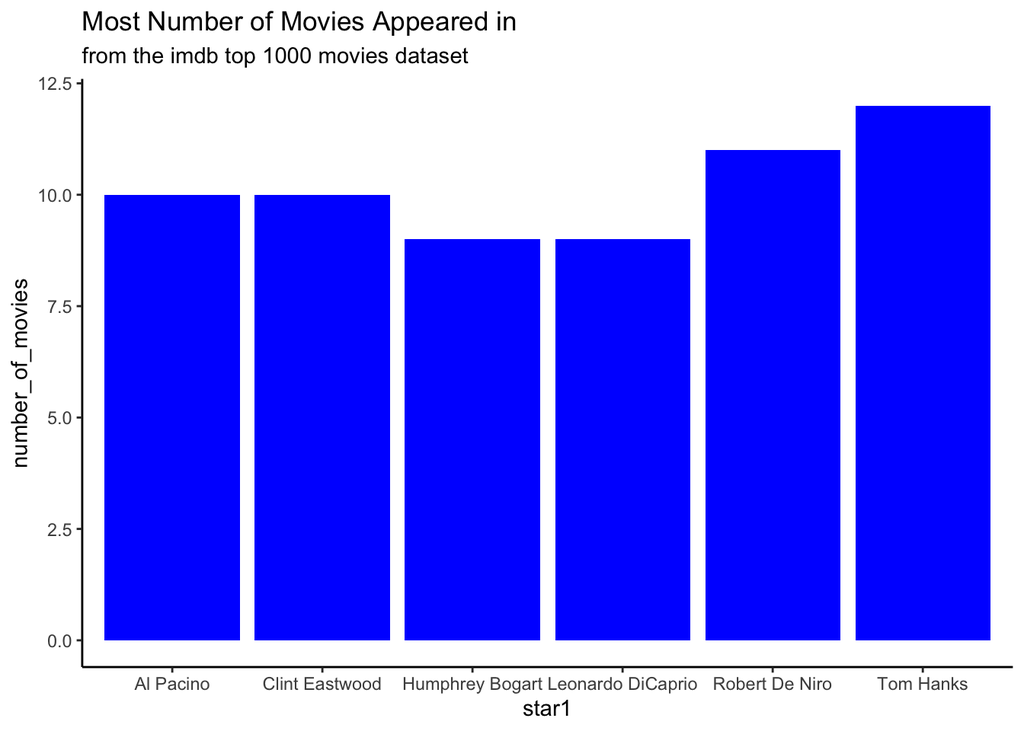

```r
imdbstar1count3top <- imdbstar1count3 %>%
  slice_max(number_of_movies, n = 6)

imdbstar1count3viz <- ggplot(imdbstar1count3top, aes(star1, number_of_movies))+
  geom_bar(fill = "blue", stat = "identity")+
  theme_classic()+
  labs(title = "Most Number of Movies Appeared in", subtitle = "from the imdb top 1000 movies dataset")

print(imdbstar1count3viz)
```

Now that I found out which starting actor(star1) has the most movies on this list, I am going to figure out which supporting actor(shown as star2 in dataset) with a minimum appearance count of 2 has the most appearances on this list, I will begin by first finding the count of the supporting actors and then visualizing them using ggplot.

```r
imdbstar2count <- imdbtop1000v8 %>%
  group_by(star2)%>%
  summarize(number_of_movies = n())

imdbstar2count2 <- imdbstar2count%>%
  filter(number_of_movies >= 2)%>%
  arrange(desc(number_of_movies))

print(imdbstar2count2)
```

```
## # A tibble: 112 × 2
##    star2        number_of_movies
##    <chr>                   <int>
##  1 Emma Watson                 7
##  2 Matt Damon                  5
##  3 Brad Pitt                   4
##  4 Chris Evans                 4
##  5 Diane Keaton                4
##  6 Ed Harris                   4
##  7 Ian McKellen                4
##  8 Julie Delpy                 4
##  9 Kate Winslet                4
## 10 Meryl Streep                4
## # ℹ 102 more rows
```

[figure not shown]

```r
imdbstar2count2top <- imdbstar2count%>%
  slice_max(number_of_movies, n = 3)

imdbstar2count2viz <- ggplot(imdbstar2count2top, aes(star2, number_of_movies))+
  geom_bar(fill = "blue", stat= "identity")+
  theme_classic()+
  labs(title = "Most Number of Movies Appearing in by a Supporting Actor", subtitle = "from the imdb top 1000 movies dataset")+
  scale_x_discrete(guide = guide_axis(n.dodge = 2))

print (imdbstar2count2viz)
```

The next thing I would like to figure out is which director, with a minimum count of 3 movies, has the most appearances on this list of top 1000 movies. I begin like I did with the previous tasks by counting the number of appearances and finding out who has the most.

```r
imdbdirectorcount <- imdbtop1000v8%>%
  group_by(director)%>%
  summarize(number_of_movies = n())

imdbdirectorcount3 <- imdbdirectorcount%>%
  filter(number_of_movies >= 3)%>%
  arrange(desc(number_of_movies))

print(imdbdirectorcount3)
```

```
## # A tibble: 97 × 2
##    director          number_of_movies
##    <chr>                        <int>
##  1 Alfred Hitchcock                14
##  2 Steven Spielberg                13
##  3 Hayao Miyazaki                  11
##  4 Akira Kurosawa                  10
##  5 Martin Scorsese                 10
##  6 Billy Wilder                     9
##  7 Stanley Kubrick                  9
##  8 Woody Allen                      9
##  9 Christopher Nolan                8
## 10 Clint Eastwood                   8
## # ℹ 87 more rows
```

The most appearances on this list are by Alfred Hitchcock with 14 and then Steven Spielberg with 13. I can visualize this using ggplot.

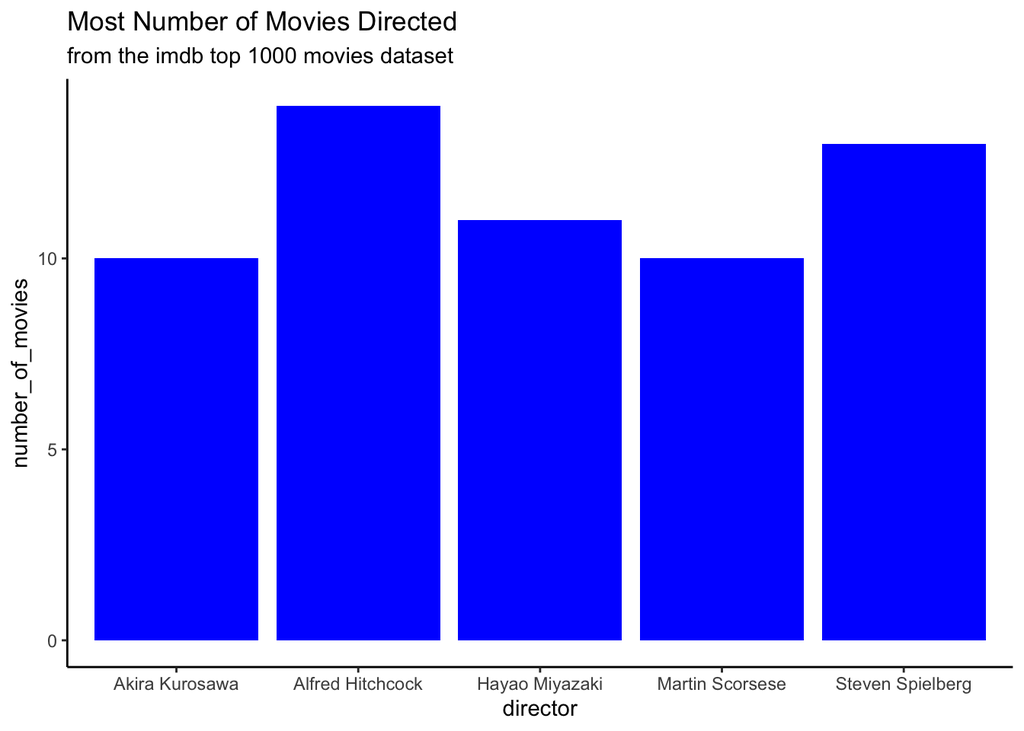

```r
imdbdirectorcount3top <- imdbdirectorcount3%>%
  slice_max(number_of_movies, n = 5)

imdbdirectorcount3viz <- ggplot(imdbdirectorcount3top, aes(director, number_of_movies))+
  geom_bar(fill = "blue", stat = "identity")+
  theme_classic()+
  labs(title = "Most Number of Movies Directed", subtitle = "from the imdb top 1000 movies dataset")

print(imdbdirectorcount3viz)
```

After finding the top 5 directors I am wondering what directors have the highest imdb rating.

```r
imdbdirectoravgimdb <- imdbtop1000v8%>%
  group_by(director)%>%
  summarize(average_imdb_rating = mean(imdb_rating))

imdbdirectoravgimdb1 <- imdbdirectoravgimdb %>%
  arrange(desc(average_imdb_rating))

print(imdbdirectoravgimdb1)
```

```
## # A tibble: 548 × 2
##    director           average_imdb_rating
##    <chr>                            <dbl>
##  1 Frank Darabont                    8.95
##  2 Irvin Kershner                    8.7
##  3 Lana Wachowski                    8.7
##  4 Fernando Meirelles                8.6
##  5 George Lucas                      8.6
##  6 Masaki Kobayashi                  8.6
##  7 Roberto Benigni                   8.6
##  8 Sudha Kongara                     8.6
##  9 Thomas Kail                       8.6
## 10 Milos Forman                      8.5
## # ℹ 538 more rows
```